# Tim Gormly

## Module 5, Task 1

### 2/11/2023

In this notebook, we will load a CSV containing data related to the Titanic Disaster. The data will be loaded into a pandas DataFrame and analyzed.

## 1. Load

The data we are using is stored in a csv file in a public github repository. We can pass the csv file's URL as an argument to the read_csv pandas function to load this data from the web into a Pandas DataFrame.

```python
import pandas as pd

titanic = pd.read_csv('https://vincentarelbundock.github.io/Rdatasets/csv/carData/TitanicSurvival.csv')
```

## 2. View

We will first adjust the precision of pandas to 2 decimal places

```python
pd.set_option('display.precision', 2)
```

Next we will view the head and tail of the DataFrame

```python
titanic.head()
```

|  | Unnamed: 0 | survived | sex | age | passengerClass |
| --- | --- | --- | --- | --- | --- |
| 0 | Allen, Miss. Elisabeth Walton | yes | female | 29.00 | 1st |
| 1 | Allison, Master. Hudson Trevor | yes | male | 0.92 | 1st |
| 2 | Allison, Miss. Helen Loraine | no | female | 2.00 | 1st |
| 3 | Allison, Mr. Hudson Joshua Crei | no | male | 30.00 | 1st |
| 4 | Allison, Mrs. Hudson J C (Bessi | no | female | 25.00 | 1st |

```python
titanic.tail()
```

|  | Unnamed: 0 | survived | sex | age | passengerClass |
| --- | --- | --- | --- | --- | --- |
| 1304 | Zabour, Miss. Hileni | no | female | 14.5 | 3rd |
| 1305 | Zabour, Miss. Thamine | no | female | NaN | 3rd |
| 1306 | Zakarian, Mr. Mapriededer | no | male | 26.5 | 3rd |
| 1307 | Zakarian, Mr. Ortin | no | male | 27.0 | 3rd |
| 1308 | Zimmerman, Mr. Leo | no | male | 29.0 | 3rd |

Calling the head() returns the first 5 rows, and calling tail() returns the last 5 rows. The two of these can be used to quickly get a sense of the scope of a DataFrame. How many rows does the DataFrame contain? How is the data formatted? Etc.

## 3. Headings

The headings of the columns can be improved. "Unnamed: 0" is not descriptive, so we will change that to "name". "passengerClass" is descriptive, but is causing its column to be unnecessarily wide. We can shorten this to "Class"

```python
titanic.columns = ['name', 'survived', 'sex', 'age', 'class']
```

We used .columns to assign a new list of column names. Note that all 5 columns had to be included in the list of column names. We can use the .head() method to check our work.

```python
titanic.head()
```

|  | name | survived | sex | age | class |
| --- | --- | --- | --- | --- | --- |
| 0 | Allen, Miss. Elisabeth Walton | yes | female | 29.00 | 1st |
| 1 | Allison, Master. Hudson Trevor | yes | male | 0.92 | 1st |
| 2 | Allison, Miss. Helen Loraine | no | female | 2.00 | 1st |
| 3 | Allison, Mr. Hudson Joshua Crei | no | male | 30.00 | 1st |
| 4 | Allison, Mrs. Hudson J C (Bessi | no | female | 25.00 | 1st |

## 4. Describe

The .describe function can be used to review simple descriptive statistics for all columns with numeric values.

```python
titanic.describe()
```

|  | age |
| --- | --- |
| count | 1046.00 |
| mean | 29.88 |
| std | 14.41 |
| min | 0.17 |
| 25% | 21.00 |
| 50% | 28.00 |
| 75% | 39.00 |
| max | 80.00 |

The age column is the only column with numberic data, so it is the only column returned.

## 5. Survivors

```python
(titanic.survived == 'yes').describe()
```

```
count      1309
unique        2
top       False
freq        809
Name: survived, dtype: object
```

## 6. Histogram

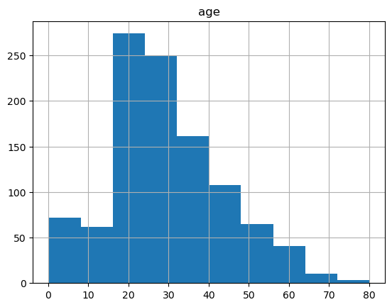

```python
histogram = titanic.hist()
```